# OpenMind_Zachary_Zivalich

# 1 The intellectual humility Survey

### Addressing the relability of the IH-6 with cronbach’s alpha

First, the dataset needs some recording. I’m going to recode the two non-reverse coded questions so all the questions share the same correlative slope, this eliminates some alpha functions down the line

```r
library("tidyverse")
library("readxl")
library(knitr)
library(kableExtra)
#reading in data
df = read_excel("C:/Users/zacha/Desktop/task_dat.xlsx")
#recoding gender
df$D2 = ifelse(df$D2=="Female",1,0)
#reverse coding the two on reversed survey questions
df$IH3Pre = 8-df$IH3Pre
df$IH4Pre = 8-df$IH4Pre
df
```

| OMID | D1 | D2 | D3 | D4 | D6 | IH1Pre | IH2Pre | IH3Pre | IH4Pre | IH5Pre | IH6Pre | GMPre | GMPost | SEPre | SEPost | AffPol2Pre | AffPol2Post | AnxietyPre | AnxietyPost | GBSSPre | GBSSPost | BelongPre | BelongPost |
| --- | --- | --- | --- | --- | --- | --- | --- | --- | --- | --- | --- | --- | --- | --- | --- | --- | --- | --- | --- | --- | --- | --- | --- |
| 4.188309e+12 | 19 | 0 | (Hispanic/Latino) | Moderate/middle-of-the-road | Roman Catholic | 2 | 2 | 5 | 6 | 2 | 2 | NA | NA | NA | NA | NA | NA | 3.75 | 3.5 | 3.3333333333333299 | 3.3333333333333299 | NA | NA |
| 6.264772e+11 | 21 | 1 | (African American/Black)(Hispanic/Latino) | Progressive/left | Roman Catholic | 4 | 2 | 1 | 1 | 1 | 1 | NA | NA | NA | NA | 60 | 60 | NA | NA | NA | NA | NA | NA |
| 4.645127e+12 | 22 | 1 | (South Asian) | Don't know/not political | Muslim | 7 | 4 | 6 | 5 | 2 | 2 | NA | NA | NA | NA | NA | NA | NA | NA | NA | NA | NA | NA |
| 9.123506e+12 | 20 | 0 | (East or Southeast Asian) | Don't know/not political | Nothing in particular | 2 | 1 | 2 | 3 | 1 | 3 | 3 | NA | NA | NA | NA | NA | NA | NA | 2.3333333333333299 | NA | NA | NA |
| 3.794779e+12 | 29 | 0 | (White/Caucasian) | Very progressive/left | Atheist | 3 | 1 | 5 | 3 | 2 | 2 | 7 | NA | 5.75 | NA | NA | NA | 3.5 | NA | NA | NA | NA | NA |
| 2.593830e+11 | 80 | 0 | (White/Caucasian) | Slightly progressive/left | Agnostic | 2 | 2 | 4 | 4 | 2 | 2 | 4.6666666666666599 | NA | NA | NA | 31 | NA | NA | NA | 3.6666666666666599 | NA | NA | NA |
| 4.838901e+12 | 21 | 1 | (African American/Black) | Slightly progressive/left | Something else | 3 | 2 | 4 | 4 | 2 | 2 | NA | NA | 5.75 | 4.75 | NA | NA | 2.5 | 2.75 | 2.3333333333333299 | 3.6666666666666599 | NA | NA |
| 5.268924e+12 | 20 | 1 | (White/Caucasian) | Moderate/middle-of-the-road | Nothing in particular | 5 | 5 | 2 | 2 | 3 | 2 | NA | NA | 6 | 6 | NA | NA | 2.75 | 3.5 | 2.6666666666666599 | 3 | NA | NA |
| 2.911398e+12 | 20 | 1 | (Hispanic/Latino) | Progressive/left | Prefer not to say | 2 | 2 | 6 | 4 | 2 | 3 | NA | NA | 4.25 | 5 | NA | NA | NA | NA | 3.3333333333333299 | 3.3333333333333299 | NA | NA |
| 7.754940e+12 | 18 | 1 | (Hispanic/Latino)(White/Caucasian) | Moderate/middle-of-the-road | Roman Catholic | 4 | 3 | 2 | 2 | 2 | 1 | NA | NA | 5.5 | 5.75 | NA | NA | 2.75 | 2.5 | NA | NA | NA | NA |

[output cut: 990 more lines]

Next, I run the Alpha function from the psych library. The Alpha is around a .6, signaling a weak correaltion and realiability

```r
library(psych)
dfalpha = data.frame(df[,7:12])
alpha(dfalpha)
```

```
Reliability analysis
Call: alpha(x = dfalpha)
```

|  | raw_alpha | std.alpha | G6(smc) | average_r | S/N | ase | mean | sd | median_r |
| --- | --- | --- | --- | --- | --- | --- | --- | --- | --- |
|  | 0.624181 | 0.650709 | 0.6907455 | 0.2369269 | 1.862942 | 0.01311525 | 2.484965 | 0.7462919 | 0.1146465 |

```
 lower alpha upper     95% confidence boundaries
0.6 0.62 0.65

 Reliability if an item is dropped:
```

|  | raw_alpha | std.alpha | G6(smc) | average_r | S/N | alpha se | var.r | med.r |
| --- | --- | --- | --- | --- | --- | --- | --- | --- |
| IH1Pre | 0.5954580 | 0.6122011 | 0.6519395 | 0.2399663 | 1.578656 | 0.01398544 | 0.04382959 | 0.1088035 |
| IH2Pre | 0.5762370 | 0.5962904 | 0.6414404 | 0.2280410 | 1.477028 | 0.01473305 | 0.04661683 | 0.1088035 |
| IH3Pre | 0.5920439 | 0.6388097 | 0.6192737 | 0.2612974 | 1.768624 | 0.01450625 | 0.02796793 | 0.3261782 |
| IH4Pre | 0.5803660 | 0.6366802 | 0.6179149 | 0.2595221 | 1.752396 | 0.01499703 | 0.02868339 | 0.3261782 |
| IH5Pre | 0.5744680 | 0.5856518 | 0.6294974 | 0.2203858 | 1.413429 | 0.01502330 | 0.04664216 | 0.1013436 |
| IH6Pre | 0.5669403 | 0.5741030 | 0.6165360 | 0.2123486 | 1.347986 | 0.01522299 | 0.04426930 | 0.1026250 |

```
 Item statistics
```

|  | n | raw.r | std.r | r.cor | r.drop | mean | sd |
| --- | --- | --- | --- | --- | --- | --- | --- |
| IH1Pre | 2073 | 0.5607681 | 0.5950165 | 0.4635846 | 0.3166264 | 2.518090 | 1.2737269 |
| IH2Pre | 2073 | 0.5914800 | 0.6279552 | 0.5073360 | 0.3663399 | 2.397492 | 1.2268055 |
| IH3Pre | 2072 | 0.6371638 | 0.5360986 | 0.4542540 | 0.3457979 | 3.305019 | 1.5817079 |
| IH4Pre | 2073 | 0.6339554 | 0.5410021 | 0.4603248 | 0.3625431 | 2.670526 | 1.4912824 |
| IH5Pre | 2073 | 0.5664755 | 0.6490993 | 0.5430399 | 0.3952756 | 2.032320 | 0.9486921 |
| IH6Pre | 2073 | 0.5872756 | 0.6712988 | 0.5804735 | 0.4242714 | 1.986975 | 0.9317046 |

```
Non missing response frequency for each item
          1    2    3    4    5    6    7 miss
IH1Pre 0.19 0.41 0.24 0.08 0.04 0.03 0.01    0
IH2Pre 0.19 0.48 0.16 0.09 0.04 0.02 0.01    0
IH3Pre 0.12 0.29 0.16 0.14 0.22 0.06 0.02    0
IH4Pre 0.23 0.37 0.12 0.12 0.12 0.03 0.01    0
IH5Pre 0.28 0.52 0.15 0.04 0.01 0.01 0.00    0
IH6Pre 0.29 0.52 0.13 0.04 0.01 0.00 0.00    0
```

### Addressing the multidimensionaility of the IH-6 survey

A nice way of determining whether something is measuring the same concept (concept validity) is to visualize the distribution of the survey questions. In this case, if all the distributions for the items had the same distribution, and the negative questions had a mirror of this distibution, than the questions have good validity.However, looking at the histograms, questions 3 and 4 have widely different distributions than the other questions.

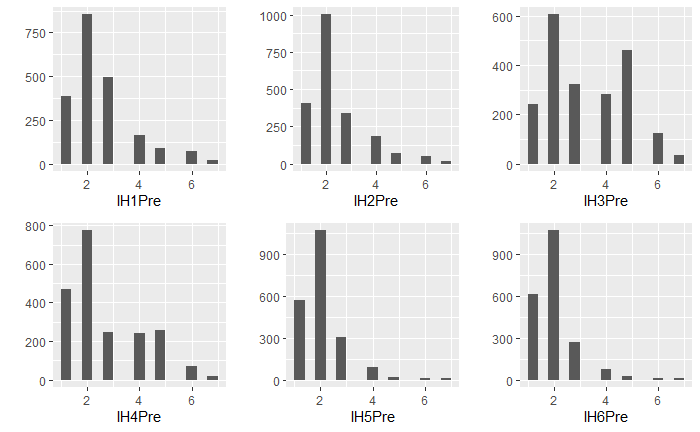

```r
p6 <- qplot(IH6Pre, data = df,binwidth=.4)
grid.arrange(p1, p2, p3,p4,p5,p6, nrow = 2)
```

```r
pca <- prcomp(na.omit(dfalpha))
summary(pca)
```

```
Importance of components:
                          PC1    PC2     PC3     PC4     PC5     PC6
Standard deviation     1.9966 1.6240 0.95554 0.92060 0.89160 0.66621
Proportion of Variance 0.4142 0.2741 0.09488 0.08807 0.08261 0.04612
Cumulative Proportion  0.4142 0.6883 0.78320 0.87127 0.95388 1.00000
```

### Factorial Analysis of IH-6

```r
dfalpha = data.frame(df[,7:12])
factanal(x=na.omit(dfalpha),factors = 2, roation="varimax")
```

```
Call:
factanal(x = na.omit(dfalpha), factors = 2, roation = "varimax")

Uniquenesses:
IH1Pre IH2Pre IH3Pre IH4Pre IH5Pre IH6Pre
 0.677  0.659  0.381  0.317  0.594  0.518

Loadings:
       Factor1 Factor2
IH1Pre  0.568
IH2Pre  0.582
IH3Pre          0.786
IH4Pre          0.825
IH5Pre  0.631
IH6Pre  0.689

               Factor1 Factor2
SS loadings      1.540   1.315
Proportion Var   0.257   0.219
Cumulative Var   0.257   0.476

Test of the hypothesis that 2 factors are sufficient.
The chi square statistic is 87.19 on 4 degrees of freedom.
The p-value is 5.19e-18
```

```r
#library(lavaan)
df.model<- 'positive =~ IH1Pre + IH2Pre + IH5Pre + IH6Pre
            negative =~ IH3Pre + IH4Pre'

fit = lavaan::cfa(df.model,data = dfalpha)
lavaan::summary(fit, fit.measures=TRUE)
```

```
lavaan 0.6-6 ended normally after 38 iterations

  Estimator                                         ML
  Optimization method                           NLMINB
  Number of free parameters                         13

                                                  Used       Total
  Number of observations                          2072        2073

Model Test User Model:

  Test statistic                                98.206
  Degrees of freedom                                 8
  P-value (Chi-square)                           0.000

Model Test Baseline Model:

  Test statistic                              2713.005
  Degrees of freedom                                15
  P-value                                        0.000

User Model versus Baseline Model:

  Comparative Fit Index (CFI)                    0.967
  Tucker-Lewis Index (TLI)                       0.937

Loglikelihood and Information Criteria:

  Loglikelihood user model (H0)             -18778.814
  Loglikelihood unrestricted model (H1)     -18729.711

  Akaike (AIC)                               37583.628
  Bayesian (BIC)                             37656.900
  Sample-size adjusted Bayesian (BIC)        37615.597

Root Mean Square Error of Approximation:

  RMSEA                                          0.074
  90 Percent confidence interval - lower         0.061
  90 Percent confidence interval - upper         0.087
```

[output cut: 23 more lines]

```
Covariances:
                   Estimate  Std.Err  z-value  P(>|z|)
  positive ~~
    negative          0.139    0.030    4.682    0.000

Variances:
                   Estimate  Std.Err  z-value  P(>|z|)
   .IH1Pre            1.119    0.042   26.452    0.000
   .IH2Pre            1.000    0.039   25.707    0.000
   .IH5Pre            0.530    0.023   23.040    0.000
   .IH6Pre            0.444    0.022   19.803    0.000
   .IH3Pre            0.962    0.262    3.673    0.000
   .IH4Pre            0.694    0.260    2.673    0.008
    positive          0.503    0.044   11.503    0.000
    negative          1.538    0.270    5.699    0.000
```

# 2 Correlates of Affective Polarization

### Correlational Matrix

To look at the relationship between different survey answers and affective polarization, first I cleaned up the data set to make everyone numerical and drop the categorical variables. I explore further down the categorical variables using some EDA visuals.

```r
x = df[,c(2:3,7:24)]
x[] <- lapply(x, function(x) as.numeric(as.character(x)))
```

[output not shown]

```r
round_df <- function(df, digits) {
  nums <- vapply(df, is.numeric, FUN.VALUE = logical(1))

  df[,nums] <- round(df[,nums], digits = digits)

  (df)
}
x = round_df(x,1)
x
```

| D1 | D2 | IH1Pre | IH2Pre | IH3Pre | IH4Pre | IH5Pre | IH6Pre | GMPre | GMPost | SEPre | SEPost | AffPol2Pre | AffPol2Post | AnxietyPre | AnxietyPost | GBSSPre | GBSSPost | BelongPre | BelongPost |
| --- | --- | --- | --- | --- | --- | --- | --- | --- | --- | --- | --- | --- | --- | --- | --- | --- | --- | --- | --- |
| 19 | 0 | 2 | 2 | 3 | 2 | 2 | 2 | NA | NA | NA | NA | NA | NA | 3.8 | 3.5 | 3.3 | 3.3 | NA | NA |
| 21 | 1 | 4 | 2 | 7 | 7 | 1 | 1 | NA | NA | NA | NA | 60 | 60 | NA | NA | NA | NA | NA | NA |
| 22 | 1 | 7 | 4 | 2 | 3 | 2 | 2 | NA | NA | NA | NA | NA | NA | NA | NA | NA | NA | NA | NA |
| 20 | 0 | 2 | 1 | 6 | 5 | 1 | 3 | 3.0 | NA | NA | NA | NA | NA | NA | NA | 2.3 | NA | NA | NA |
| 29 | 0 | 3 | 1 | 3 | 5 | 2 | 2 | 7.0 | NA | 5.8 | NA | NA | NA | 3.5 | NA | NA | NA | NA | NA |
| 80 | 0 | 2 | 2 | 4 | 4 | 2 | 2 | 4.7 | NA | NA | NA | 31 | NA | NA | NA | 3.7 | NA | NA | NA |
| 21 | 1 | 3 | 2 | 4 | 4 | 2 | 2 | NA | NA | 5.8 | 4.8 | NA | NA | 2.5 | 2.8 | 2.3 | 3.7 | NA | NA |
| 20 | 1 | 5 | 5 | 6 | 6 | 3 | 2 | NA | NA | 6.0 | 6.0 | NA | NA | 2.8 | 3.5 | 2.7 | 3.0 | NA | NA |
| 20 | 1 | 2 | 2 | 2 | 4 | 2 | 3 | NA | NA | 4.2 | 5.0 | NA | NA | NA | NA | 3.3 | 3.3 | NA | NA |
| 18 | 1 | 4 | 3 | 6 | 6 | 2 | 1 | NA | NA | 5.5 | 5.8 | NA | NA | 2.8 | 2.5 | NA | NA | NA | NA |

[output cut: 990 more lines]

```r
cor(x, use = "pairwise.complete.obs")
```

```
                     D1          D2       IH1Pre      IH2Pre      IH3Pre      IH4Pre       IH5Pre
D1           1.00000000 -0.11739354 -0.060533019 -0.05642481  0.04383320  0.05404013 -0.051113997
D2          -0.11739354  1.00000000  0.091944079  0.12384189  0.08393120  0.04206704  0.098726564
IH1Pre      -0.06053302  0.09194408  1.000000000  0.42470820  0.02029944  0.03273982  0.308851651
IH2Pre      -0.05642481  0.12384189  0.424708203  1.00000000  0.07654219  0.06106618  0.343504652
IH3Pre       0.04383320  0.08393120  0.020299444  0.07654219  1.00000000  0.65054278  0.090581665
IH4Pre       0.05404013  0.04206704  0.032739818  0.06106618  0.65054278  1.00000000  0.114646547
IH5Pre      -0.05111400  0.09872656  0.308851651  0.34350465  0.09058167  0.11464655  1.000000000
IH6Pre      -0.04890405  0.07784293  0.367636441  0.36765539  0.10293565  0.09972674  0.492438425
GMPre        0.04777143 -0.04668125 -0.150190784 -0.16155446 -0.21342237 -0.17064492 -0.178871517
GMPost       0.04489658  0.01163271 -0.057154605 -0.10043317 -0.17285733 -0.16994232 -0.153037930
SEPre        0.16929602  0.02132432  0.076350510 -0.03258140 -0.13731178 -0.09671380 -0.066135390
SEPost       0.19789165  0.02260977  0.019970575 -0.02957254 -0.07815007 -0.09228993 -0.153478558
AffPol2Pre  -0.01214035  0.16305165 -0.003964685  0.13102011  0.10989685  0.08220278 -0.094838721
AffPol2Post  0.01958721  0.13599566 -0.074882698  0.13799188  0.05149249  0.07109884 -0.009995949
AnxietyPre  -0.22557728  0.25045455 -0.071187346  0.02684688  0.22325508  0.18287059  0.007000533
AnxietyPost -0.16988237  0.29230042 -0.044027624  0.05774107  0.22071684  0.20604633  0.034739649
GBSSPre     -0.07307883  0.06579941 -0.026475602  0.06849918  0.07948601  0.07628733 -0.127384575
GBSSPost    -0.07484959 -0.01974889 -0.019701095  0.06617477  0.07052635  0.09108238 -0.051710001
BelongPre    0.03905745 -0.05358266 -0.065691747 -0.16996124 -0.14362512 -0.10194457 -0.194773613
BelongPost   0.05186524 -0.08348518 -0.000904338 -0.12583813 -0.06243293 -0.04850839 -0.215313460
                  IH6Pre        GMPre      GMPost       SEPre      SEPost   AffPol2Pre  AffPol2Post
D1          -0.048904047  0.047771434  0.04489658  0.16929602  0.19789165 -0.012140349  0.019587208
D2           0.077842931 -0.046681253  0.01163271  0.02132432  0.02260977  0.163051651  0.135995665
IH1Pre       0.367636441 -0.150190784 -0.05715460  0.07635051  0.01997058 -0.003964685 -0.074882698
IH2Pre       0.367655390 -0.161554460 -0.10043317 -0.03258140 -0.02957254  0.131020105  0.137991880
IH3Pre       0.102935653 -0.213422372 -0.17285733 -0.13731178 -0.07815007  0.109896852  0.051492494
IH4Pre       0.099726742 -0.170644919 -0.16994232 -0.09671380 -0.09228993  0.082202785  0.071098843
IH5Pre       0.492438425 -0.178871517 -0.15303793 -0.06613539 -0.15347856 -0.094838721 -0.009995949
IH6Pre       1.000000000 -0.174423377 -0.16630142 -0.10274572 -0.13227725 -0.008826021 -0.045498867
GMPre       -0.174423377  1.000000000  0.60411997  0.22269791  0.08707537  0.056652215 -0.051914738
GMPost      -0.166301420  0.604119973  1.00000000  0.15707063  0.22994889 -0.101611633 -0.174711353
SEPre       -0.102745718  0.222697906  0.15707063  1.00000000  0.81139779  0.063114211  0.047100436
SEPost      -0.132277247  0.087075366  0.22994889  0.81139779  1.00000000  0.031546057  0.011204101
AffPol2Pre  -0.008826021  0.056652215 -0.10161163  0.06311421  0.03154606  1.000000000  0.762164288
AffPol2Post -0.045498867 -0.051914738 -0.17471135  0.04710044  0.01120410  0.762164288  1.000000000
AnxietyPre  -0.020278979 -0.131640646 -0.05002429 -0.30856539 -0.28734359  0.105133006  0.137593703
AnxietyPost  0.024703185 -0.107873946 -0.13203886 -0.28766314 -0.33789570  0.060218065  0.094692719
GBSSPre     -0.089783357 -0.008270172 -0.01487522 -0.05886150 -0.05585075  0.323893656  0.209182528
GBSSPost    -0.020790748 -0.029116985 -0.05104347 -0.05065359 -0.06755682  0.318156709  0.458520181
```

[output cut: 8 more lines]

```
IH4Pre       0.182870586  0.206046334  0.076287328  0.091082381 -0.10194457 -0.048508390
IH5Pre       0.007000533  0.034739649 -0.127384575 -0.051710001 -0.19477361 -0.215313460
IH6Pre      -0.020278979  0.024703185 -0.089783357 -0.020790748 -0.17688154 -0.264142480
GMPre       -0.131640646 -0.107873946 -0.008270172 -0.029116985  0.23347323  0.051597138
GMPost      -0.050024289 -0.132038859 -0.014875221 -0.051043466  0.07823620  0.327254571
SEPre       -0.308565385 -0.287663136 -0.058861499 -0.050653592  0.49663916  0.474546456
SEPost      -0.287343590 -0.337895703 -0.055850749 -0.067556822  0.48692618  0.618486058
AffPol2Pre   0.105133006  0.060218065  0.323893656  0.318156709 -0.08657987 -0.125718308
AffPol2Post  0.137593703  0.094692719  0.209182528  0.458520181 -0.17544303 -0.250309920
AnxietyPre   1.000000000  0.832158395  0.167656164  0.017604166 -0.10690182 -0.209915126
AnxietyPost  0.832158395  1.000000000  0.053987828  0.003308873 -0.24867243 -0.231051477
GBSSPre      0.167656164  0.053987828  1.000000000  0.636236830  0.09598132  0.075281064
GBSSPost     0.017604166  0.003308873  0.636236830  1.000000000  0.11147349  0.099022530
BelongPre   -0.106901822 -0.248672425  0.095981320  0.111473485  1.00000000  0.709930089
BelongPost  -0.209915126 -0.231051477  0.075281064  0.099022530  0.70993009  1.000000000
```

### Catgorical trends in relation to affective polarization

I looked at the Ethnicity, political stances, and religion of participants and said relation to affective polarization

```r
#creating box plots for each categorical variable and eliminating the x-ais labels because there are so may potential answers
y = as.numeric(df$AffPol2Pre)
```

```
NAs introduced by coercion
```

```r
p1 <- ggplot(df, aes(x=D3, y=y)) + geom_boxplot() + theme(axis.title.x=element_blank(),  axis.text.x=element_blank(), axis.ticks.x=element_blank()) + ggtitle("Ethnicity")
p2 <- ggplot(df, aes(x=D4, y=y)) + geom_boxplot() + theme(axis.title.x=element_blank(),  axis.text.x=element_blank(), axis.ticks.x=element_blank()) + ggtitle("Political Opinion")
p3 <- ggplot(df, aes(x=D6, y=y)) + geom_boxplot() + theme(axis.title.x=element_blank(),  axis.text.x=element_blank(), axis.ticks.x=element_blank()) + ggtitle("Religion")
```

looking at the box plots, most groups had very similar relationships with effective polarization. Political Opinion’s however did have a noticeable effect. I suspect that right leaning test takers score lower overall. I was going to recode the variables so that it was more like a spectrum of progressive at 1 and conservative at 7, but I thought that was outside of the scope of this project. I looked at the post affective polarization, and it looks like the intervention does not work on certain groups, which is very interesting.

```r
#doing the same for affective polarization post
y = as.numeric(df$AffPol2Post)
```

```
NAs introduced by coercion
```

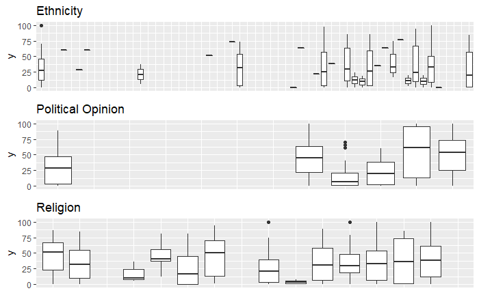

```r
p1 <- ggplot(df, aes(x=D3, y=y)) + geom_boxplot() + theme(axis.title.x=element_blank(),  axis.text.x=element_blank(), axis.ticks.x=element_blank()) + ggtitle("Ethnicity")
p2 <- ggplot(df, aes(x=D4, y=y)) + geom_boxplot() + theme(axis.title.x=element_blank(),  axis.text.x=element_blank(), axis.ticks.x=element_blank()) + ggtitle("Political Opinion")
p3 <- ggplot(df, aes(x=D6, y=y)) + geom_boxplot() + theme(axis.title.x=element_blank(),  axis.text.x=element_blank(), axis.ticks.x=element_blank()) + ggtitle("Religion")
grid.arrange(p1, p2, p3, nrow = 3)
```

# 3 using a linear mixed model on the pre and post affective polarization data

First, I used tidyverse to reorganize the dataset so that participants had multiple cells for each time they were asked for their affective polarization.

```r
library(rstatix)
dfn = df %>%
  gather( key = "prepost", value= "change",AffPol2Pre, AffPol2Post) %>%
  convert_as_factor(OMID,prepost)%>%
  select(OMID,D1,D2,prepost,change)%>%
  rename(Age = D1 , Gender = D2)
dfn$change = as.numeric(dfn$change)
dfn
```

| OMID | Age | Gender | prepost | change |
| --- | --- | --- | --- | --- |
| 4188308688106 | 19 | 0 | AffPol2Pre | NA |
| 626477162159 | 21 | 1 | AffPol2Pre | 60 |
| 4645127094563 | 22 | 1 | AffPol2Pre | NA |
| 9123506116893 | 20 | 0 | AffPol2Pre | NA |
| 3794779413108 | 29 | 0 | AffPol2Pre | NA |
| 259383041571 | 80 | 0 | AffPol2Pre | 31 |
| 4838900664658 | 21 | 1 | AffPol2Pre | NA |
| 5268923541355 | 20 | 1 | AffPol2Pre | NA |
| 2911397594925 | 20 | 1 | AffPol2Pre | NA |
| 7754939640757 | 18 | 1 | AffPol2Pre | NA |

[output cut: 990 more lines]

```r
NA
```

Next, I ran a linear mix-effects model on the pre and post affective polarization data using the lme4 package. looking at the summary table, pre and post results were significantly different.

```r
library(lme4)
library(lmerTest)
library(psycho)
M1 = lmer(change ~ prepost + (1|OMID), data =dfn)
summary(M1)
```

```
Linear mixed model fit by REML. t-tests use Satterthwaite's method ['lmerModLmerTest']
Formula: change ~ prepost + (1 | OMID)
   Data: dfn

REML criterion at convergence: 7433.2

Scaled residuals:
     Min       1Q   Median       3Q      Max
-2.87134 -0.44634 -0.00834  0.36951  3.02433

Random effects:
 Groups   Name        Variance Std.Dev.
 OMID     (Intercept) 578.8    24.06
 Residual             183.8    13.56
Number of obs: 811, groups:  OMID, 526

Fixed effects:
                  Estimate Std. Error      df t value Pr(>|t|)
(Intercept)         32.395      1.401 791.118   23.12   <2e-16 ***
prepostAffPol2Pre   10.072      1.103 321.275    9.13   <2e-16 ***
---
Signif. codes:  0 ‘***’ 0.001 ‘**’ 0.01 ‘*’ 0.05 ‘.’ 0.1 ‘ ’ 1

Correlation of Fixed Effects:
            (Intr)
prpstAffP2P -0.559
```

Below is a graph of the change from pre to post affective polarization tests with fixed and random effects accounted for. It is a positive relationship taking both effects into account.

[figure not shown]

```r
library(sjPlot)
plot_model(M1, title = " Change in Affective polarization")
```

# 4 using a linear mixed model on age and gender

Next, I added in age and gender variables into the model to see if they played a part in the success of the intervention. looking at the coefficients, the pre-post results were no longer significant while taking into account the age and gender of the participant. Perhaps certain males are much less likely to react to the intervention and females very likely to. This assumption would require a deeper dive into the data to determine.

```r
M2 = lmer(change ~ prepost * Age * Gender + (1|OMID), data =dfn)
summary(M2)
```

```
Linear mixed model fit by REML. t-tests use Satterthwaite's method ['lmerModLmerTest']
Formula: change ~ prepost * Age * Gender + (1 | OMID)
   Data: dfn

REML criterion at convergence: 7414.6

Scaled residuals:
    Min      1Q  Median      3Q     Max
-2.8670 -0.4708 -0.0131  0.3795  3.1677

Random effects:
 Groups   Name        Variance Std.Dev.
 OMID     (Intercept) 562.0    23.71
 Residual             183.6    13.55
Number of obs: 811, groups:  OMID, 526

Fixed effects:
                              Estimate Std. Error        df t value Pr(>|t|)
(Intercept)                   19.79407    6.51594 723.76296   3.038  0.00247 **
prepostAffPol2Pre             10.91068    5.72235 343.43052   1.907  0.05740 .
Age                            0.32881    0.23701 585.66067   1.387  0.16587
Gender                        17.98647    8.14471 767.41961   2.208  0.02751 *
prepostAffPol2Pre:Age         -0.13360    0.21933 355.16564  -0.609  0.54283
prepostAffPol2Pre:Gender       1.71153    6.98786 337.91094   0.245  0.80666
Age:Gender                    -0.44041    0.30156 662.63246  -1.460  0.14465
prepostAffPol2Pre:Age:Gender   0.08541    0.27154 349.14512   0.315  0.75328
---
Signif. codes:  0 ‘***’ 0.001 ‘**’ 0.01 ‘*’ 0.05 ‘.’ 0.1 ‘ ’ 1

Correlation of Fixed Effects:
            (Intr) prAP2P Age    Gender prAP2P:A pAP2P:G Ag:Gnd
prpstAffP2P -0.752
Age         -0.931  0.785
Gender      -0.800  0.601  0.745
prpstAP2P:A  0.745 -0.945 -0.850 -0.596
prpstAP2P:G  0.616 -0.819 -0.643 -0.708  0.774
Age:Gender   0.732 -0.617 -0.786 -0.931  0.668    0.735
prpAP2P:A:G -0.602  0.764  0.687  0.700 -0.808   -0.943  -0.799
```

Finally, I used a package to plot this change. Age did very little to effect the improvement of affective polarization.However, Gender had an interesting relationship with the effects of the intervention. When taking into the effects of Gender, the intervention was more like to either be positive or negative. This results are very interesting and raises many questions about the effects of gender on OpenMind’s intervention.

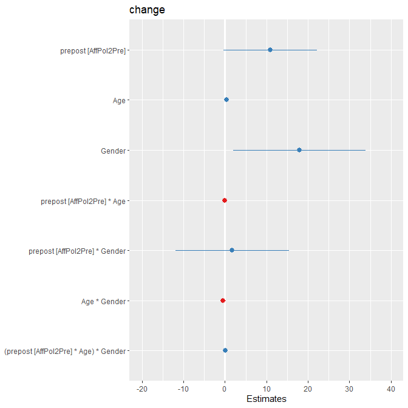

```r
plot_model(M2)
```

```r
dfn %>%
  group_by(Gender)%>%
  summarise(mean(change, na.rm = TRUE))
```

| Gender | mean(change, na.rm = TRUE) |
| --- | --- |
| 0 | 34.04590 |
| 1 | 42.43083 |